# 02_2_Analysis

The notebook shows the process of analysis for different features. The corpus comprised several author’s corpora:

8 male authors  
- nkrja selected authors: Karamzin, Zhukovsky, Pushkin, Baratynsky, Lermontov  
- poems published in periodicals between 1835 and 1840 by: Benediktov, Kozlov, Timofeev

7 female authors + one mistification  
- poems published between 1835 and 1840 by female authors: Rostopchina, Teplova, Shakhova, Pavlova, Kul’man;  
- poems by earlier women poets M. Pospelova and A. Bunina;  
- mysterious “female prodigy” A. Smirnova (not included in the paper)

Basic statistics and overview of the data. Some authors have unproportionally big corpora, so I randomly select 10000 words from their corpora for further analysis.

```r
load("../data/02_2_analysis_data_tidy.Rda")

n_poems <- analysis %>%
  group_by(author, text_ID) %>%
  count() %>%
  ungroup() %>%
  group_by(author) %>%
  count() %>%
  rename(n_poems = n)

n_tokens <- analysis %>%
  group_by(author) %>%
  count() %>%
  ungroup() %>%
  rename(n_tokens = n)

auth_gender <- tibble(author = c("БаратынскийЕА", "Бенедиктов В.Г.", "Бунина А.",
                                 "ЖуковскийВА", "КарамзинНМ", "Козлов И.И.", "Кульман Е.Б.",
                                 "ЛермонтовМЮ", "Павлова К.К.", "Поспелова М.", "ПушкинАС",
                                 "Ростопчина Е.П.", "Смирнова А.", "Теплова Н.С.",
                                 "Тимофеев А.В.", "Шахова Е.Н." ),
                      gender = c("m", "m", "f", "m", "m", "m", "f", "m", "f",
                                 "f", "m", "f", "f", "f", "m", "f"))

base_statistics <- auth_gender %>%
  left_join(n_poems, by = "author") %>%
  left_join(n_tokens, by = "author") %>%
  arrange(gender, desc = T)

base_statistics
```

| author | gender | n_poems | n_tokens |
| --- | --- | --- | --- |
| Бунина А. | f | 103 | 51608 |
| Кульман Е.Б. | f | 15 | 3888 |
| Павлова К.К. | f | 16 | 2140 |
| Поспелова М. | f | 13 | 8856 |
| Ростопчина Е.П. | f | 39 | 8205 |
| Смирнова А. | f | 51 | 14275 |
| Теплова Н.С. | f | 56 | 4417 |
| Шахова Е.Н. | f | 30 | 5588 |
| БаратынскийЕА | m | 208 | 31728 |
| Бенедиктов В.Г. | m | 30 | 6151 |

[output cut: 6 more lines]

```r
rm(n_poems, n_tokens, auth_gender)
```

```r
glimpse(analysis)

analysis$pos %>% table()

analysis %>%
  filter(!author %in% c("ПушкинАС", "ЖуковскийВА", "КарамзинНМ", "ЛермонтовМЮ",
                        "Бунина А.", "БаратынскийЕА")) %>%
  group_by(author) %>%
  count() %>%
  ungroup() %>%
  summarise(mean_corpus = mean(n))
# mean number of words in a corpus from periodicals: ~7000 words

# randomly select only 10 000 words form large corpora
random_big <- analysis %>%
  filter(author %in% c("ПушкинАС", "ЖуковскийВА", "КарамзинНМ", "ЛермонтовМЮ",
                        "Бунина А.", "БаратынскийЕА")) %>%
  group_by(author) %>%
  sample_n(10000) %>%
  ungroup()

randomized <- analysis %>%
  filter(!author %in% c("ПушкинАС", "ЖуковскийВА", "КарамзинНМ", "ЛермонтовМЮ",
                        "Бунина А.", "БаратынскийЕА")) %>%
  rbind(random_big)

#write.csv(randomized, "../data/02_2_random_sample_1.csv")
```

```r
# example for calculating proportion of POS for each author
nouns <- randomized %>%
  filter(pos == "S") %>%
  group_by(author) %>%
  summarise(n_nouns = n(),
            n_f_nouns = sum(fem),
            prop_f_nouns = n_f_nouns/n_nouns) %>%
  arrange(prop_f_nouns, desc = FALSE)

nouns
```

| author | n_nouns | n_f_nouns | prop_f_nouns |
| --- | --- | --- | --- |
| ЖуковскийВА | 3718 | 1142 | 0.3071544 |
| Бунина А. | 3802 | 1188 | 0.3124671 |
| КарамзинНМ | 3817 | 1227 | 0.3214566 |
| Павлова К.К. | 742 | 244 | 0.3288410 |
| Кульман Е.Б. | 1435 | 476 | 0.3317073 |
| ПушкинАС | 3509 | 1188 | 0.3385580 |
| Ростопчина Е.П. | 2817 | 954 | 0.3386581 |
| БаратынскийЕА | 3498 | 1185 | 0.3387650 |
| Поспелова М. | 3546 | 1202 | 0.3389735 |
| Тимофеев А.В. | 3655 | 1253 | 0.3428181 |

[output cut: 6 more lines]

```
## [1] "Proportion of feminine POS"
```

| author | gender | n_poems | n_tokens | prop_f_nouns | prop_f_adj | prop_f_verb | prop_f_apro | prop_f_spro | prop_intj |
| --- | --- | --- | --- | --- | --- | --- | --- | --- | --- |
| Бунина А. | f | 103 | 51608 | 0.3124671 | 0.2396694 | 0.06305770 | 0.3550000 | 0.07659574 | 0.0010851031 |
| Кульман Е.Б. | f | 15 | 3888 | 0.3317073 | 0.2155340 | 0.10950081 | 0.3291925 | 0.06624606 | 0.0059156379 |
| Павлова К.К. | f | 16 | 2140 | 0.3288410 | 0.3404255 | 0.04696133 | 0.3333333 | 0.08119658 | 0.0158878505 |
| Поспелова М. | f | 13 | 8856 | 0.3389735 | 0.3530534 | 0.06661891 | 0.3844282 | 0.06589958 | 0.0074525745 |
| Ростопчина Е.П. | f | 39 | 8205 | 0.3386581 | 0.3426819 | 0.12347685 | 0.3549488 | 0.13935231 | 0.0059719683 |
| Смирнова А. | f | 51 | 14275 | 0.3654848 | 0.2361111 | 0.07059241 | 0.3370577 | 0.03730797 | 0.0128896673 |
| Теплова Н.С. | f | 56 | 4417 | 0.3944659 | 0.3798701 | 0.12461538 | 0.4216216 | 0.09767442 | 0.0090559203 |
| Шахова Е.Н. | f | 30 | 5588 | 0.4004988 | 0.4105263 | 0.17136150 | 0.4533333 | 0.12199313 | 0.0076950608 |
| БаратынскийЕА | m | 208 | 31728 | 0.3387650 | 0.3330810 | 0.09190231 | 0.3768116 | 0.14982877 | 0.0017965204 |
| Бенедиктов В.Г. | m | 30 | 6151 | 0.3475559 | 0.3329609 | 0.09863589 | 0.3578431 | 0.11299435 | 0.0024386279 |

[output cut: 6 more lines]

```
## [1] "Mean values for parts of speech in feminine forms"
```

| pos | n | f_pos | proc_f |
| --- | --- | --- | --- |
| A | 14831 | 4695 | 0.31656665 |
| APRO | 4982 | 1869 | 0.37515054 |
| S | 48322 | 16726 | 0.34613634 |
| SPRO | 12864 | 1236 | 0.09608209 |
| V | 21481 | 1814 | 0.08444672 |

```r
randomized <- randomized %>%
  mutate(lemma = str_extract(analysis, "\\[\\{'lex': '.*?',")) %>%
  mutate(lemma = str_remove_all(lemma, "[[:punct:]]|lex|[[:space:]]"))
```

```
## [1] "extract lemmas from analysis"
```

|  | word | lemma |
| --- | --- | --- |
| 1 | ты | ты |
| 2 | дух | дух |
| 3 | мне | я |
| 4 | теперь | теперь |
| 5 | красен | красный |
| 6 | красен | красный |

NB! The dictionaries for abstractness / concreteness indexes were prepared by a research group from Kazan Federal University; current lists are publicly available and can be found at: https://kpfu.ru/tehnologiya-sozdaniya-semanticheskih-elektronnyh.html  
On methodology of lists compilation, see: Solovyev V.D., Volskaya Y.A., Andreeva M.I., Zaikin A.A. (2022). “Russian dictionary with concreteness/abstractness indices.” Russian Journal for Linguistics, 26-2, 515-549.

```r
# Abstractness / concreteness dictionaries cleaning & merge
dict_adj <- read.delim("../data/dicts/adj_concreteness.csv", sep = ";") %>%
  mutate(word = str_remove_all(word, "[[:punct:]]|[[:space:]]"),
         index_c_a = str_replace_all(index_c_a, ",", "\\.")) %>%
  mutate(index_c_a = as.numeric(index_c_a))

dict_noun <- read.delim("../data/dicts/nouns_concreteness.csv", sep = ";") %>%
  mutate(word = str_remove_all(word, "[[:punct:]]|[[:space:]]"),
         index_c_a = str_replace_all(index_c_a, ",", "\\.")) %>%
  mutate(index_c_a = as.numeric(index_c_a))

glimpse(dict_adj)
```

```
## Rows: 23,880
## Columns: 3
## $ word      <chr> "новенький", "кожаная", "самодельный", "шерстяной", "тоненьк…
## $ score     <chr> "76", "60", "49", "49", "46", "42", "42", "40", "36", "33", …
## $ index_c_a <dbl> 5.330733, 5.094345, 4.891820, 4.891820, 4.828641, 4.737670, …
```

```r
glimpse(dict_noun)
```

```
## Rows: 63,951
## Columns: 3
## $ word      <chr> "туфельки", "шаровары", "сапожки", "горсовета", "плащи", "дж…
## $ score     <chr> "35", "35", "32", "31", "31", "31", "29", "27", "27", "26,75…
## $ index_c_a <dbl> 4.555348, 4.555348, 4.465736, 4.433987, 4.433987, 4.433987, …
```

```r
dictionaries <- rbind(dict_adj, dict_noun) %>% rename(lemma = word) %>% select(-score)

randomized <- randomized %>% left_join(dictionaries, by = "lemma")
```

|  | X.2 | X.1 | X | text_ID | author | word | analysis | grammar | pos | fem | lemma | index_c_a |
| --- | --- | --- | --- | --- | --- | --- | --- | --- | --- | --- | --- | --- |
| 1 | 1 | 604379 | 604379 | posp_6 | Поспелова М. | ты | [{'analysis': [{'lex': 'ты', 'gr': 'SPRO,ед,2-л=им'}], 'text': 'ты'}, {'text': '\\n'}] | 'SPRO,ед,2-л=им' | SPRO | 0 | ты | NA |
| 2 | 2 | 32373 | 32373 | P_1590 | Козлов И.И. | дух | [{'analysis': [{'lex': 'дух', 'gr': 'S,муж,неод=(вин,ед\|им,ед)'}], 'text': 'дух'}, {'text': '\\n'}] | 'S,муж,неод=(вин,ед\|им,ед)' | S | 0 | дух | -0.4845689 |
| 3 | 3 | 22723 | 22723 | P_923 | Ростопчина Е.П. | мне | [{'analysis': [{'lex': 'я', 'gr': 'SPRO,ед,1-л=(пр\|дат)'}], 'text': 'мне'}, {'text': '\\n'}] | 'SPRO,ед,1-л=(пр\|дат)' | SPRO | 0 | я | NA |
| 4 | 4 | 602903 | 602903 | posp_3 | Поспелова М. | теперь | [{'analysis': [{'lex': 'теперь', 'gr': 'ADV='}], 'text': 'теперь'}, {'text': '\\n'}] | 'ADV=' | ADV | 0 | теперь | NA |
| 5 | 5 | 23757 | 23757 | P_984 | Бенедиктов В.Г. | красен | [{'analysis': [{'lex': 'красный', 'gr': 'A=ед,кр,муж'}], 'text': 'красен'}, {'text': '\\n'}] | 'A=ед,кр,муж' | A | 0 | красный | 2.2154764 |
| 6 | 5 | 23757 | 23757 | P_984 | Бенедиктов В.Г. | красен | [{'analysis': [{'lex': 'красный', 'gr': 'A=ед,кр,муж'}], 'text': 'красен'}, {'text': '\\n'}] | 'A=ед,кр,муж' | A | 0 | красный | 0.7993515 |

| lemma | index_c_a |
| --- | --- |
| дух | -0.4845689304 |
| красный | 2.2154763837 |
| красный | 0.7993515265 |
| красный | 2.2154763837 |
| красный | 0.7993515265 |
| сын | -0.0555527992 |
| голубиный | 0.5945848906 |
| лик | -0.4405393760 |
| судьба | -2.1349943409 |
| туча | 0.4347181904 |

[output cut: 9990 more lines]

```r
glimpse(randomized)
```

```
## Rows: 132,072
## Columns: 12
## $ X.2       <int> 1, 2, 3, 4, 5, 5, 6, 6, 7, 8, 9, 10, 11, 12, 13, 14, 15, 16,…
## $ X.1       <int> 604379, 32373, 22723, 602903, 23757, 23757, 23757, 23757, 44…
## $ X         <int> 604379, 32373, 22723, 602903, 23757, 23757, 23757, 23757, 44…
## $ text_ID   <chr> "posp_6", "P_1590", "P_923", "posp_3", "P_984", "P_984", "P_…
## $ author    <chr> "Поспелова М.", "Козлов И.И.", "Ростопчина Е.П.", "Поспелова…
## $ word      <chr> "ты", "дух", "мне", "теперь", "красен", "красен", "красен", …
## $ analysis  <chr> "[{'analysis': [{'lex': 'ты', 'gr': 'SPRO,ед,2-л=им'}], 'tex…
## $ grammar   <chr> "'SPRO,ед,2-л=им'", "'S,муж,неод=(вин,ед|им,ед)'", "'SPRO,ед…
## $ pos       <chr> "SPRO", "S", "SPRO", "ADV", "A", "A", "A", "A", "SPRO", "SPR…
## $ fem       <int> 0, 0, 0, 0, 0, 0, 0, 0, 0, 0, 0, 0, 0, 0, 0, 0, 1, 0, 0, 0, …
## $ lemma     <chr> "ты", "дух", "я", "теперь", "красный", "красный", "красный",…
## $ index_c_a <dbl> NA, -0.4845689, NA, NA, 2.2154764, 0.7993515, 2.2154764, 0.7…
```

```r
abstract_concrete <- randomized %>%
  filter(!is.na(index_c_a)) %>%
  group_by(author) %>%
  summarise(mean_ac = mean(index_c_a))

head(abstract_concrete, 16)
```

| author | mean_ac |
| --- | --- |
| БаратынскийЕА | -0.48831843 |
| Бенедиктов В.Г. | -0.38060377 |
| Бунина А. | -0.47923794 |
| ЖуковскийВА | -0.27463575 |
| КарамзинНМ | -0.50162557 |
| Козлов И.И. | -0.37375957 |
| Кульман Е.Б. | -0.18528250 |
| ЛермонтовМЮ | -0.22530338 |
| Павлова К.К. | -0.09400388 |
| Поспелова М. | -0.57719697 |

[output cut: 6 more lines]

Add vector model lists of closely thematic words

```r
w2v_lists <- read.csv("../data/02_1_notions_vectors.csv")
head(w2v_lists)
```

|  | X | notion | words |
| --- | --- | --- | --- |
| 1 | 1 | любовь | любовь разуверение ветренный запретный неизлечимый душа охлаждать виновница осуществляться оледенить поверенный возобновляться честолюбие крепить угаснуть наитие заблуждаться эльвира скоротечность сбл… |
| 2 | 2 | дом | дом хоромы кладовая сумасшедший опустелый вечерня передняя лачуга келья выстраивать избушка вельможный часовня лавочка галерея уютный потемки домик лачужка запросто изукрашивать сбежаться забор погреб… |
| 3 | 3 | семья | семья семейственный наследие лачуга драгоя староста кровный пенат гостеприимный хата неприхотливый атаман угощать приютный наследный лиственный поместье узница немилый кров отслуживать аркадий сват со… |
| 4 | 4 | уста | уста прикосновение оледенить ланита излетать прильнуть впивать напитывать лобзание губа жгучий щечка наливаться персей ланит обвевать гиена потускнуть воспаленный кальян тиховейный недосказывать взвол… |
| 5 | 5 | грудь | грудь оледенить перси охватывать вливаться вкрадываться взволноваться истомляться вздыматься наливаться вежда сердце лилейный прижимать воспаленный мятежно каштановый прильнуть стыдливо вздымать излет… |
| 6 | 6 | глаз | глаз око взор лицо проступать ресница сомкнутый слезинка впалый смоль эмаль зеница туманить напитывать внимательно ямка завертываться вглядываться пылание заткнуть зевнуть ноздря глазок забытье профил… |

How percentage of a theme-related words is calculated:

```r
n_tokens <- randomized %>%
  group_by(author) %>%
  count(sort = T) %>%
  rename(total = n) %>%
  arrange(author, desc = T)

x <- as.vector(str_split_fixed(w2v_lists$words[6], pattern = " ", n = 30))

# example how it works
randomized %>%
  filter(lemma %in% x) %>%
  group_by(author) %>%
  count() %>%
  arrange(author, desc = T) %>%
  left_join(n_tokens, by = "author") %>%
  mutate(proc_theme = n/total) %>%
  rename(!!x[1]:=proc_theme) %>%
  arrange(author, desc = T)
```

| author | n | total | глаз |
| --- | --- | --- | --- |
| БаратынскийЕА | 68 | 10252 | 0.006632852 |
| Бенедиктов В.Г. | 48 | 6292 | 0.007628735 |
| Бунина А. | 45 | 10123 | 0.004445323 |
| ЖуковскийВА | 54 | 10195 | 0.005296714 |
| КарамзинНМ | 44 | 10192 | 0.004317111 |
| Козлов И.И. | 39 | 7106 | 0.005488320 |
| Кульман Е.Б. | 11 | 3945 | 0.002788340 |
| ЛермонтовМЮ | 69 | 10258 | 0.006726457 |
| Павлова К.К. | 5 | 2197 | 0.002275831 |
| Поспелова М. | 51 | 8928 | 0.005712366 |

[output cut: 6 more lines]

```r
# main counter
x <- NULL
y <- NULL
themes <- NULL
w2v_results <- list()

for (i in 1:nrow(w2v_lists)) {
  # select list of words
  x <- as.vector(str_split_fixed(w2v_lists$words[i], pattern = " ", n = 30))

  # save theme name
  themes[i] <- x[1]

  # count number of words related
  y <- randomized %>%
  filter(lemma %in% x) %>%
  group_by(author) %>%
  count() %>%
  arrange(author, desc = T) %>%
  left_join(n_tokens, by = "author") %>%
  mutate(proc_theme = n/total)

  # store results
  w2v_results[[i]] <- y$proc_theme
}

w2v_results
```

```
## [[1]]
##  [1] 0.010827156 0.009535919 0.003358688 0.005983325 0.009419152 0.013228258
##  [7] 0.001520913 0.007408852 0.007282658 0.010752688 0.005964020 0.008884151
## [13] 0.006153208 0.015656453 0.005076142 0.012762238
##
## [[2]]
##  [1] 0.0005852517 0.0001589320 0.0009878495 0.0017655714 0.0002943485
##  [6] 0.0007036307 0.0002534854 0.0009748489 0.0027309968 0.0004480287
## [11] 0.0012710207 0.0009476427 0.0003456858 0.0006709908 0.0022680635
## [16] 0.0003496503
##
## [[3]]
##  [1] 0.0009754194 0.0004767959 0.0005927097 0.0004904365 0.0007849294
##  [6] 0.0002814523 0.0007604563 0.0005849093 0.0018206645 0.0004480287
## [11] 0.0007821666 0.0011845534 0.0002074115 0.0006709908 0.0012237762
##
## [[4]]
##  [1] 0.0021459227 0.0049268913 0.0021732688 0.0012751349 0.0008830455
##  [6] 0.0016887138 0.0017743980 0.0016572431 0.0004551661 0.0004480287
## [11] 0.0009777083 0.0005922767 0.0009679204 0.0029076269 0.0031320877
## [16] 0.0010489510
##
## [[5]]
##  [1] 0.004877097 0.014780674 0.004148968 0.003923492 0.009615385 0.009850830
##  [7] 0.001520913 0.004776760 0.002275831 0.006496416 0.002835354 0.009121061
## [13] 0.005047013 0.008499217 0.005616157 0.007692308
##
## [[6]]
##  [1] 0.006632852 0.007628735 0.004445323 0.005296714 0.004317111 0.005488320
##  [7] 0.002788340 0.006726457 0.002275831 0.005712366 0.003030896 0.004619758
## [13] 0.003180310 0.005144263 0.004752133 0.004895105
##
## [[7]]
##  [1] 0.0021459227 0.0014303878 0.0019756989 0.0010789603 0.0028453689
##  [6] 0.0053475936 0.0038022814 0.0013647885 0.0022758307 0.0049283154
## [11] 0.0012710207 0.0008291874 0.0025580752 0.0026839633 0.0036721028
## [16] 0.0040209790
##
## [[8]]
##  [1] 0.0016582130 0.0009535919 0.0007902796 0.0010789603 0.0037284144
```

[output cut: 49 more lines]

```
##  [1] 0.0010729614 0.0001589320 0.0011854193 0.0003923492 0.0012755102
##  [6] 0.0007604563 0.0004874244 0.0004551661 0.0004480287 0.0005866250
## [11] 0.0002369107 0.0013136062 0.0002236636 0.0001080030 0.0008741259
##
## [[18]]
##  [1] 0.0025360905 0.0055626192 0.0021732688 0.0013732222 0.0011773940
##  [6] 0.0021108922 0.0010139417 0.0015597582 0.0013654984 0.0003360215
## [11] 0.0008799374 0.0008291874 0.0017284292 0.0022366361 0.0032400907
## [16] 0.0024475524
##
## [[19]]
##  [1] 0.0011705033 0.0028607756 0.0034574731 0.0032368808 0.0058869702
##  [6] 0.0014072615 0.0048162231 0.0015597582 0.0004551661 0.0038082437
## [11] 0.0004888541 0.0013030088 0.0114767699 0.0017893089 0.0034560968
## [16] 0.0041958042
```

```r
#themes

# table pivoting
w2v_results_t <- as.tibble(do.call(rbind, w2v_results))
colnames(w2v_results_t) <- as.vector(n_tokens$author)

w2v_results_t$theme <- themes

w2v_results_t
```

| БаратынскийЕА | Бенедиктов В.Г. | Бунина А. | ЖуковскийВА | КарамзинНМ | Козлов И.И. | Кульман Е.Б. | ЛермонтовМЮ | Павлова К.К. | Поспелова М. | ПушкинАС | Ростопчина Е.П. | Смирнова А. | Теплова Н.С. | Тимофеев А.В. | Шахова Е.Н. | theme |
| --- | --- | --- | --- | --- | --- | --- | --- | --- | --- | --- | --- | --- | --- | --- | --- | --- |
| 0.0108271557 | 0.0095359186 | 0.0033586881 | 0.0059833252 | 0.0094191523 | 0.0132282578 | 0.0015209125 | 0.0074088516 | 7.282658e-03 | 0.0107526882 | 0.0059640203 | 0.0088841507 | 0.0061532080 | 0.0156564527 | 0.0050761421 | 0.0127622378 | любовь |
| 0.0005852517 | 0.0001589320 | 0.0009878495 | 0.0017655714 | 0.0002943485 | 0.0007036307 | 0.0002534854 | 0.0009748489 | 2.730997e-03 | 0.0004480287 | 0.0012710207 | 0.0009476427 | 0.0003456858 | 0.0006709908 | 0.0022680635 | 0.0003496503 | дом |
| 0.0009754194 | 0.0004767959 | 0.0005927097 | 0.0004904365 | 0.0007849294 | 0.0002814523 | 0.0007604563 | 0.0005849093 | 1.820665e-03 | 0.0004480287 | 0.0007821666 | 0.0011845534 | 0.0002074115 | 0.0006709908 | 0.0012237762 | 0.0009754194 | семья |
| 0.0021459227 | 0.0049268913 | 0.0021732688 | 0.0012751349 | 0.0008830455 | 0.0016887138 | 0.0017743980 | 0.0016572431 | 4.551661e-04 | 0.0004480287 | 0.0009777083 | 0.0005922767 | 0.0009679204 | 0.0029076269 | 0.0031320877 | 0.0010489510 | уста |
| 0.0048770972 | 0.0147806739 | 0.0041489677 | 0.0039234919 | 0.0096153846 | 0.0098508303 | 0.0015209125 | 0.0047767596 | 2.275831e-03 | 0.0064964158 | 0.0028353539 | 0.0091210614 | 0.0050470133 | 0.0084992172 | 0.0056161573 | 0.0076923077 | грудь |
| 0.0066328521 | 0.0076287349 | 0.0044453225 | 0.0052967141 | 0.0043171115 | 0.0054883197 | 0.0027883397 | 0.0067264574 | 2.275831e-03 | 0.0057123656 | 0.0030308956 | 0.0046197584 | 0.0031803097 | 0.0051442630 | 0.0047521331 | 0.0048951049 | глаз |
| 0.0021459227 | 0.0014303878 | 0.0019756989 | 0.0010789603 | 0.0028453689 | 0.0053475936 | 0.0038022814 | 0.0013647885 | 2.275831e-03 | 0.0049283154 | 0.0012710207 | 0.0008291874 | 0.0025580752 | 0.0026839633 | 0.0036721028 | 0.0040209790 | цветок |
| 0.0016582130 | 0.0009535919 | 0.0007902796 | 0.0010789603 | 0.0037284144 | 0.0019701661 | 0.0022813688 | 0.0005849093 | 4.551661e-04 | 0.0051523297 | 0.0018576457 | 0.0021321962 | 0.0055309735 | 0.0051442630 | 0.0010800302 | 0.0015734266 | природа |
| 0.0010729614 | 0.0004767959 | 0.0006914946 | 0.0004904365 | 0.0004905808 | 0.0004874244 | 0.0006843958 | 0.0023691068 | 6.913717e-05 | 0.0010800302 | 0.0010489510 | 0.0010729614 | 0.0004767959 | 0.0006914946 | 0.0004904365 | 0.0004905808 | бал |
| 0.0071205618 | 0.0060394151 | 0.0033586881 | 0.0032368808 | 0.0048076923 | 0.0080213904 | 0.0012674271 | 0.0043868200 | 2.730997e-03 | 0.0079525090 | 0.0023464998 | 0.0075811419 | 0.0047704646 | 0.0089465444 | 0.0034560968 | 0.0117132867 | печаль |

[output cut: 9 more lines]

```r
w2v_fin <- w2v_results_t %>%
  pivot_longer(!theme, names_to = "author", values_to = "proc_theme") %>%
  pivot_wider(names_from = theme, values_from = proc_theme)

w2v_fin
```

| author | любовь | дом | семья | уста | грудь | глаз | цветок | природа | бал | печаль | поэт | муза | лира | война | русский | страна | служить | лобзание | смерть |
| --- | --- | --- | --- | --- | --- | --- | --- | --- | --- | --- | --- | --- | --- | --- | --- | --- | --- | --- | --- |
| БаратынскийЕА | 0.010827156 | 0.0005852517 | 0.0009754194 | 0.0021459227 | 0.004877097 | 0.006632852 | 0.0021459227 | 0.0016582130 | 1.072961e-03 | 0.007120562 | 0.0012680453 | 0.0029262583 | 0.0019508389 | 0.0006827936 | 0.0020483808 | 0.0034139680 | 0.0010729614 | 0.0025360905 | 0.0011705033 |
| Бенедиктов В.Г. | 0.009535919 | 0.0001589320 | 0.0004767959 | 0.0049268913 | 0.014780674 | 0.007628735 | 0.0014303878 | 0.0009535919 | 4.767959e-04 | 0.006039415 | 0.0011125238 | 0.0023839797 | 0.0039732994 | 0.0014303878 | 0.0033375715 | 0.0033375715 | 0.0001589320 | 0.0055626192 | 0.0028607756 |
| Бунина А. | 0.003358688 | 0.0009878495 | 0.0005927097 | 0.0021732688 | 0.004148968 | 0.004445323 | 0.0019756989 | 0.0007902796 | 6.914946e-04 | 0.003358688 | 0.0014817742 | 0.0028647634 | 0.0017781290 | 0.0004939247 | 0.0012842043 | 0.0020744838 | 0.0011854193 | 0.0021732688 | 0.0034574731 |
| ЖуковскийВА | 0.005983325 | 0.0017655714 | 0.0004904365 | 0.0012751349 | 0.003923492 | 0.005296714 | 0.0010789603 | 0.0010789603 | 4.904365e-04 | 0.003236881 | 0.0010789603 | 0.0016674841 | 0.0011770476 | 0.0020598333 | 0.0036292300 | 0.0020598333 | 0.0003923492 | 0.0013732222 | 0.0032368808 |
| КарамзинНМ | 0.009419152 | 0.0002943485 | 0.0007849294 | 0.0008830455 | 0.009615385 | 0.004317111 | 0.0028453689 | 0.0037284144 | 4.905808e-04 | 0.004807692 | 0.0012755102 | 0.0037284144 | 0.0018642072 | 0.0003924647 | 0.0029434851 | 0.0012755102 | 0.0012755102 | 0.0011773940 | 0.0058869702 |
| Козлов И.И. | 0.013228258 | 0.0007036307 | 0.0002814523 | 0.0016887138 | 0.009850830 | 0.005488320 | 0.0053475936 | 0.0019701661 | 4.874244e-04 | 0.008021390 | 0.0002814523 | 0.0002814523 | 0.0019701661 | 0.0004221784 | 0.0012665353 | 0.0028145229 | 0.0007604563 | 0.0021108922 | 0.0014072615 |
| Кульман Е.Б. | 0.001520913 | 0.0002534854 | 0.0007604563 | 0.0017743980 | 0.001520913 | 0.002788340 | 0.0038022814 | 0.0022813688 | 6.843958e-04 | 0.001267427 | 0.0004874244 | 0.0025348542 | 0.0012674271 | 0.0002534854 | 0.0020278834 | 0.0010139417 | 0.0004874244 | 0.0010139417 | 0.0048162231 |
| ЛермонтовМЮ | 0.007408852 | 0.0009748489 | 0.0005849093 | 0.0016572431 | 0.004776760 | 0.006726457 | 0.0013647885 | 0.0005849093 | 2.369107e-03 | 0.004386820 | 0.0018206645 | 0.0007798791 | 0.0020471827 | 0.0008773640 | 0.0032170014 | 0.0017547280 | 0.0004551661 | 0.0015597582 | 0.0015597582 |
| Павлова К.К. | 0.007282658 | 0.0027309968 | 0.0018206645 | 0.0004551661 | 0.002275831 | 0.002275831 | 0.0022758307 | 0.0004551661 | 6.913717e-05 | 0.002730997 | 0.0003360215 | 0.0009103323 | 0.0009103323 | 0.0009103323 | 0.0036413291 | 0.0022758307 | 0.0004480287 | 0.0013654984 | 0.0004551661 |
| Поспелова М. | 0.010752688 | 0.0004480287 | 0.0004480287 | 0.0004480287 | 0.006496416 | 0.005712366 | 0.0049283154 | 0.0051523297 | 1.080030e-03 | 0.007952509 | 0.0011732499 | 0.0012320789 | 0.0015681004 | 0.0014665624 | 0.0024641577 | 0.0021281362 | 0.0005866250 | 0.0003360215 | 0.0038082437 |

[output cut: 6 more lines]

```r
# write.csv(w2v_fin, "data/w2v_perc_table.csv")
```

Merge all results together

```r
glimpse(morphology)
```

```
## Rows: 16
## Columns: 10
## $ author       <chr> "Бунина А.", "Кульман Е.Б.", "Павлова К.К.", "Поспелова М…
## $ gender       <chr> "f", "f", "f", "f", "f", "f", "f", "f", "m", "m", "m", "m…
## $ n_poems      <int> 103, 15, 16, 13, 39, 51, 56, 30, 208, 30, 456, 120, 37, 4…
## $ n_tokens     <int> 51608, 3888, 2140, 8856, 8205, 14275, 4417, 5588, 31728, …
## $ prop_f_nouns <dbl> 0.3124671, 0.3317073, 0.3288410, 0.3389735, 0.3386581, 0.…
## $ prop_f_adj   <dbl> 0.2396694, 0.2155340, 0.3404255, 0.3530534, 0.3426819, 0.…
## $ prop_f_verb  <dbl> 0.06305770, 0.10950081, 0.04696133, 0.06661891, 0.1234768…
## $ prop_f_apro  <dbl> 0.3550000, 0.3291925, 0.3333333, 0.3844282, 0.3549488, 0.…
## $ prop_f_spro  <dbl> 0.07659574, 0.06624606, 0.08119658, 0.06589958, 0.1393523…
## $ prop_intj    <dbl> 0.0010851031, 0.0059156379, 0.0158878505, 0.0074525745, 0…
```

```r
main_results <- morphology %>%
  left_join(abstract_concrete, by = "author") %>%
  left_join(w2v_fin, by = "author") %>%
  mutate(author = str_replace_all(author, "(\\w)(\\w)(\\w)$", "\\1 \\2\\.\\3\\."))

head(main_results)
```

| author | gender | n_poems | n_tokens | prop_f_nouns | prop_f_adj | prop_f_verb | prop_f_apro | prop_f_spro | prop_intj | mean_ac | любовь | дом | семья | уста | грудь | глаз | цветок | природа | бал | печаль | поэт | муза | лира | война | русский | страна | служить | лобзание | смерть |
| --- | --- | --- | --- | --- | --- | --- | --- | --- | --- | --- | --- | --- | --- | --- | --- | --- | --- | --- | --- | --- | --- | --- | --- | --- | --- | --- | --- | --- | --- |
| Бунина А. | f | 103 | 51608 | 0.3124671 | 0.2396694 | 0.06305770 | 0.3550000 | 0.07659574 | 0.001085103 | -0.47923794 | 0.003358688 | 0.0009878495 | 0.0005927097 | 0.0021732688 | 0.004148968 | 0.004445323 | 0.0019756989 | 0.0007902796 | 6.914946e-04 | 0.003358688 | 0.0014817742 | 0.0028647634 | 0.0017781290 | 0.0004939247 | 0.0012842043 | 0.0020744838 | 0.0011854193 | 0.0021732688 | 0.0034574731 |
| Кульман Е.Б. | f | 15 | 3888 | 0.3317073 | 0.2155340 | 0.10950081 | 0.3291925 | 0.06624606 | 0.005915638 | -0.18528250 | 0.001520913 | 0.0002534854 | 0.0007604563 | 0.0017743980 | 0.001520913 | 0.002788340 | 0.0038022814 | 0.0022813688 | 6.843958e-04 | 0.001267427 | 0.0004874244 | 0.0025348542 | 0.0012674271 | 0.0002534854 | 0.0020278834 | 0.0010139417 | 0.0004874244 | 0.0010139417 | 0.0048162231 |
| Павлова К.К. | f | 16 | 2140 | 0.3288410 | 0.3404255 | 0.04696133 | 0.3333333 | 0.08119658 | 0.015887850 | -0.09400388 | 0.007282658 | 0.0027309968 | 0.0018206645 | 0.0004551661 | 0.002275831 | 0.002275831 | 0.0022758307 | 0.0004551661 | 6.913717e-05 | 0.002730997 | 0.0003360215 | 0.0009103323 | 0.0009103323 | 0.0009103323 | 0.0036413291 | 0.0022758307 | 0.0004480287 | 0.0013654984 | 0.0004551661 |
| Поспелова М. | f | 13 | 8856 | 0.3389735 | 0.3530534 | 0.06661891 | 0.3844282 | 0.06589958 | 0.007452575 | -0.57719697 | 0.010752688 | 0.0004480287 | 0.0004480287 | 0.0004480287 | 0.006496416 | 0.005712366 | 0.0049283154 | 0.0051523297 | 1.080030e-03 | 0.007952509 | 0.0011732499 | 0.0012320789 | 0.0015681004 | 0.0014665624 | 0.0024641577 | 0.0021281362 | 0.0005866250 | 0.0003360215 | 0.0038082437 |
| Ростопчина Е.П. | f | 39 | 8205 | 0.3386581 | 0.3426819 | 0.12347685 | 0.3549488 | 0.13935231 | 0.005971968 | -0.59658998 | 0.008884151 | 0.0009476427 | 0.0011845534 | 0.0005922767 | 0.009121061 | 0.004619758 | 0.0008291874 | 0.0021321962 | 1.072961e-03 | 0.007581142 | 0.0013136062 | 0.0021321962 | 0.0014214641 | 0.0006913717 | 0.0034352049 | 0.0009476427 | 0.0013136062 | 0.0008291874 | 0.0013030088 |
| Смирнова А. | f | 51 | 14275 | 0.3654848 | 0.2361111 | 0.07059241 | 0.3370577 | 0.03730797 | 0.012889667 | -0.59659859 | 0.006153208 | 0.0003456858 | 0.0002074115 | 0.0009679204 | 0.005047013 | 0.003180310 | 0.0025580752 | 0.0055309735 | 4.767959e-04 | 0.004770465 | 0.0024602997 | 0.0063606195 | 0.0028346239 | 0.0005400151 | 0.0008987832 | 0.0051161504 | 0.0002236636 | 0.0017284292 | 0.0114767699 |

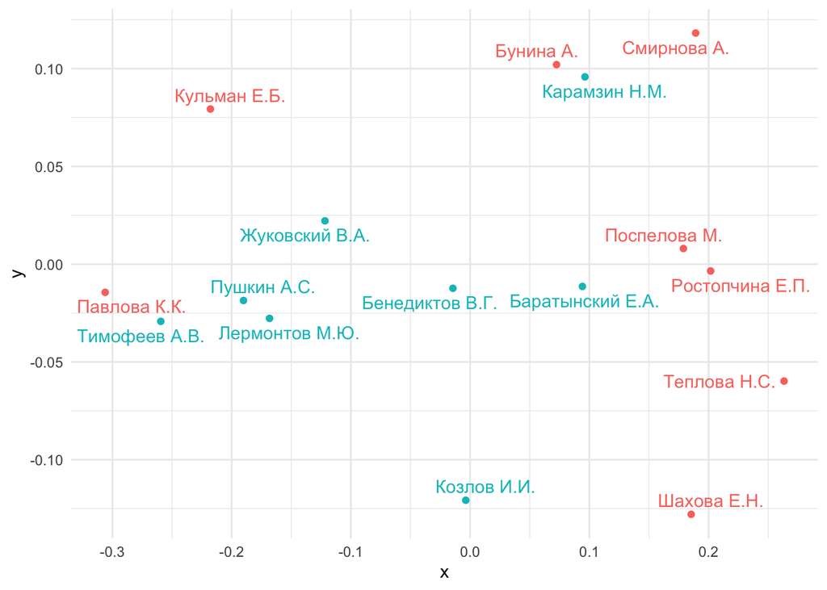

```r
# very fast projection for every feature

# labels
ids <- main_results$author
genders <- main_results$gender

t <- main_results %>% select(-author, -gender, -n_poems, -n_tokens)

values_matrix <- t %>%
  as.matrix()

distances <- dist(values_matrix, method = "euclidean")

mds <- cmdscale(distances, eig = TRUE, k = 2)

proj <- tibble(x = mds$points[,1],
               y = mds$points[,2],
               author = ids,
               gender = genders)


proj %>%
  ggplot(aes(x, y, color = gender)) +
  geom_point(data = proj, aes(x, y)) +
  geom_text_repel(aes(label = author)) +
  theme(legend.position = "None")
```

Projection only on POS features

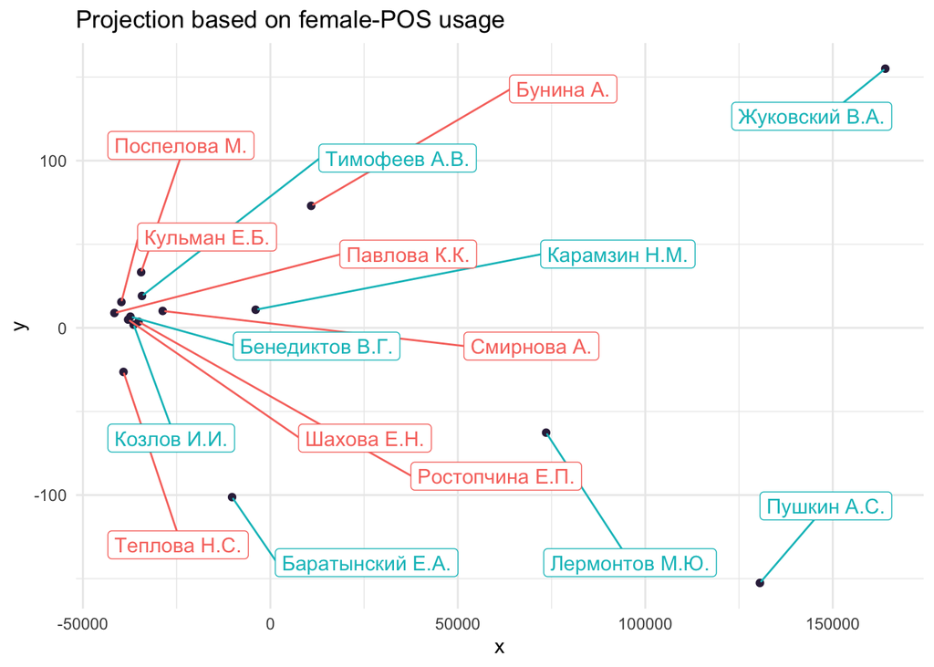

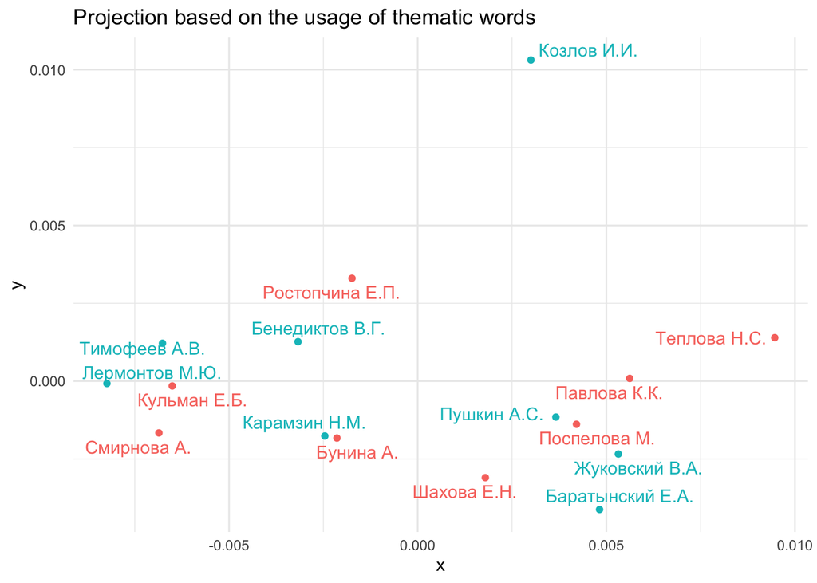

#### Grouping w2v features to 5 groups

```r
female <- rowMeans(w2v_fin[, c("любовь", "дом", "семья", "цветок", "бал")])
body <- rowMeans(w2v_fin[, c("уста", "грудь", "глаз", "лобзание")])
poetry <- rowMeans(w2v_fin[, c("поэт", "муза", "лира")])
war <- rowMeans(w2v_fin[, c("война", "русский", "страна", "служить")])
sorrow <- rowMeans(w2v_fin[, c("смерть", "печаль")])

prop_f_pron <- rowMeans(morphology[, c("prop_f_apro", "prop_f_spro")])

grouped_results <- morphology %>%
  left_join(abstract_concrete, by = "author") %>%
  cbind(prop_f_pron) %>%
  select(-prop_f_apro, -prop_f_spro)


x <- cbind(female, body, poetry, war, sorrow)
x
```

```
##            female        body       poetry          war      sorrow
##  [1,] 0.003121342 0.004047991 0.0020483808 0.0018045259 0.004145533
##  [2,] 0.002415766 0.008224730 0.0024899343 0.0020661157 0.004450095
##  [3,] 0.001521288 0.003235207 0.0020415555 0.0012595081 0.003408081
##  [4,] 0.001961746 0.002967141 0.0013078306 0.0020353114 0.003236881
##  [5,] 0.002766876 0.003998234 0.0022893773 0.0014717425 0.005347331
##  [6,] 0.004009672 0.004784689 0.0008443569 0.0013159232 0.004714326
##  [7,] 0.001404306 0.001774398 0.0014299019 0.0009456837 0.003041825
##  [8,] 0.002540501 0.003680055 0.0015492421 0.0015760649 0.002973289
##  [9,] 0.002835857 0.001593081 0.0007188953 0.0018188802 0.001593081
## [10,] 0.003531418 0.003248208 0.0013244764 0.0016613703 0.005880376
## [11,] 0.002067436 0.001930974 0.0027983936 0.0014797305 0.001417677
## [12,] 0.002583699 0.003790571 0.0016224222 0.0015969564 0.004442075
## [13,] 0.001948235 0.002730918 0.0038851810 0.0016946531 0.008123617
## [14,] 0.004074778 0.004696936 0.0017070968 0.0012764377 0.005367927
## [15,] 0.002546104 0.004185117 0.0014672362 0.0019282730 0.003456097
## [16,] 0.003719773 0.004020979 0.0025788589 0.0014999632 0.007954545
```

```r
x <- tibble(author = w2v_fin$author) %>% cbind(x)

grouped_results <- grouped_results %>%
  left_join(x, by = "author")

glimpse(grouped_results)
```

```
## Rows: 16
## Columns: 15
## $ author       <chr> "Бунина А.", "Кульман Е.Б.", "Павлова К.К.", "Поспелова М…
## $ gender       <chr> "f", "f", "f", "f", "f", "f", "f", "f", "m", "m", "m", "m…
## $ n_poems      <int> 103, 15, 16, 13, 39, 51, 56, 30, 208, 30, 456, 120, 37, 4…
## $ n_tokens     <int> 51608, 3888, 2140, 8856, 8205, 14275, 4417, 5588, 31728, …
## $ prop_f_nouns <dbl> 0.3124671, 0.3317073, 0.3288410, 0.3389735, 0.3386581, 0.…
## $ prop_f_adj   <dbl> 0.2396694, 0.2155340, 0.3404255, 0.3530534, 0.3426819, 0.…
## $ prop_f_verb  <dbl> 0.06305770, 0.10950081, 0.04696133, 0.06661891, 0.1234768…
## $ prop_intj    <dbl> 0.0010851031, 0.0059156379, 0.0158878505, 0.0074525745, 0…
## $ mean_ac      <dbl> -0.47923794, -0.18528250, -0.09400388, -0.57719697, -0.59…
## $ prop_f_pron  <dbl> 0.2157979, 0.1977193, 0.2072650, 0.2251639, 0.2471506, 0.…
## $ female       <dbl> 0.001521288, 0.001404306, 0.002835857, 0.003531418, 0.002…
## $ body         <dbl> 0.003235207, 0.001774398, 0.001593081, 0.003248208, 0.003…
## $ poetry       <dbl> 0.0020415555, 0.0014299019, 0.0007188953, 0.0013244764, 0…
## $ war          <dbl> 0.0012595081, 0.0009456837, 0.0018188802, 0.0016613703, 0…
## $ sorrow       <dbl> 0.003408081, 0.003041825, 0.001593081, 0.005880376, 0.004…
```

```r
grouped_results <- grouped_results %>%
  filter(author != "Смирнова А.")
```

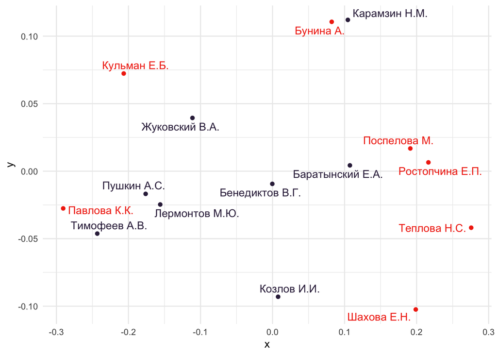

```r
ids <- grouped_results$author
genders <- grouped_results$gender

t <- grouped_results %>% select(-author, -gender, -n_poems, -n_tokens)

values_matrix <- t %>%
  as.matrix()

distances <- dist(values_matrix, method = "euclidean")

mds <- cmdscale(distances, eig = TRUE, k = 2)

proj <- tibble(x = mds$points[,1],
               y = mds$points[,2],
               author = ids,
               gender = genders)


proj %>%
  mutate(author = str_replace_all(author, "(\\w)(\\w)(\\w)$", "\\1 \\2\\.\\3\\.")) %>%
  ggplot(aes(x, y, color = gender)) +
  geom_point(data = proj, aes(x, y)) +
  geom_text_repel(aes(label = author)) +
  # geom_label_repel(aes(label = author),
  #                 box.padding = 1,
  #                 #max.overlaps = Inf,
  #                 ) +
  theme(legend.position = "None") +
  #labs(title = "Projection based on the grouped features") +
  scale_fill_manual(values = c(wes_palette("Rushmore1")[5], wes_palette("Rushmore1")[4])) +
  scale_color_manual(values = c(wes_palette("Rushmore1")[5], wes_palette("Rushmore1")[4]))
```

```r
ggsave("../plots/projection.png", plot = last_plot(), width = 8, height = 6, dpi = 300, bg = "white")

write.csv(grouped_results, "../data/02_2_grouped_results.csv")

#summary(grouped_results)
```

```r
# scaled table

#grouped_results <- read.csv("../data/02_2_grouped_results.csv")

glimpse(grouped_results)
```

```
## Rows: 15
## Columns: 15
## $ author       <chr> "Бунина А.", "Кульман Е.Б.", "Павлова К.К.", "Поспелова М…
## $ gender       <chr> "f", "f", "f", "f", "f", "f", "f", "m", "m", "m", "m", "m…
## $ n_poems      <int> 103, 15, 16, 13, 39, 56, 30, 208, 30, 456, 120, 37, 407, …
## $ n_tokens     <int> 51608, 3888, 2140, 8856, 8205, 4417, 5588, 31728, 6151, 1…
## $ prop_f_nouns <dbl> 0.3124671, 0.3317073, 0.3288410, 0.3389735, 0.3386581, 0.…
## $ prop_f_adj   <dbl> 0.2396694, 0.2155340, 0.3404255, 0.3530534, 0.3426819, 0.…
## $ prop_f_verb  <dbl> 0.06305770, 0.10950081, 0.04696133, 0.06661891, 0.1234768…
## $ prop_intj    <dbl> 0.0010851031, 0.0059156379, 0.0158878505, 0.0074525745, 0…
## $ mean_ac      <dbl> -0.47923794, -0.18528250, -0.09400388, -0.57719697, -0.59…
## $ prop_f_pron  <dbl> 0.2157979, 0.1977193, 0.2072650, 0.2251639, 0.2471506, 0.…
## $ female       <dbl> 0.001521288, 0.001404306, 0.002835857, 0.003531418, 0.002…
## $ body         <dbl> 0.003235207, 0.001774398, 0.001593081, 0.003248208, 0.003…
## $ poetry       <dbl> 0.0020415555, 0.0014299019, 0.0007188953, 0.0013244764, 0…
## $ war          <dbl> 0.0012595081, 0.0009456837, 0.0018188802, 0.0016613703, 0…
## $ sorrow       <dbl> 0.003408081, 0.003041825, 0.001593081, 0.005880376, 0.004…
```

```r
dat_for_scale <- grouped_results %>%
  select(-author, -gender, -n_poems, -n_tokens)

x <- as.data.frame(scale(dat_for_scale)) %>% mutate_if(is.numeric, round, digits = 4)

dat_scaled <- cbind(grouped_results$author, x)

write.csv(dat_scaled, "../data/02_2_grouped_results_scaled.csv")
```

```r
glimpse(grouped_results)
```

```
## Rows: 15
## Columns: 15
## $ author       <chr> "Бунина А.", "Кульман Е.Б.", "Павлова К.К.", "Поспелова М…
## $ gender       <chr> "f", "f", "f", "f", "f", "f", "f", "m", "m", "m", "m", "m…
## $ n_poems      <int> 103, 15, 16, 13, 39, 56, 30, 208, 30, 456, 120, 37, 407, …
## $ n_tokens     <int> 51608, 3888, 2140, 8856, 8205, 4417, 5588, 31728, 6151, 1…
## $ prop_f_nouns <dbl> 0.3124671, 0.3317073, 0.3288410, 0.3389735, 0.3386581, 0.…
## $ prop_f_adj   <dbl> 0.2396694, 0.2155340, 0.3404255, 0.3530534, 0.3426819, 0.…
## $ prop_f_verb  <dbl> 0.06305770, 0.10950081, 0.04696133, 0.06661891, 0.1234768…
## $ prop_intj    <dbl> 0.0010851031, 0.0059156379, 0.0158878505, 0.0074525745, 0…
## $ mean_ac      <dbl> -0.47923794, -0.18528250, -0.09400388, -0.57719697, -0.59…
## $ prop_f_pron  <dbl> 0.2157979, 0.1977193, 0.2072650, 0.2251639, 0.2471506, 0.…
## $ female       <dbl> 0.001521288, 0.001404306, 0.002835857, 0.003531418, 0.002…
## $ body         <dbl> 0.003235207, 0.001774398, 0.001593081, 0.003248208, 0.003…
## $ poetry       <dbl> 0.0020415555, 0.0014299019, 0.0007188953, 0.0013244764, 0…
## $ war          <dbl> 0.0012595081, 0.0009456837, 0.0018188802, 0.0016613703, 0…
## $ sorrow       <dbl> 0.003408081, 0.003041825, 0.001593081, 0.005880376, 0.004…
```

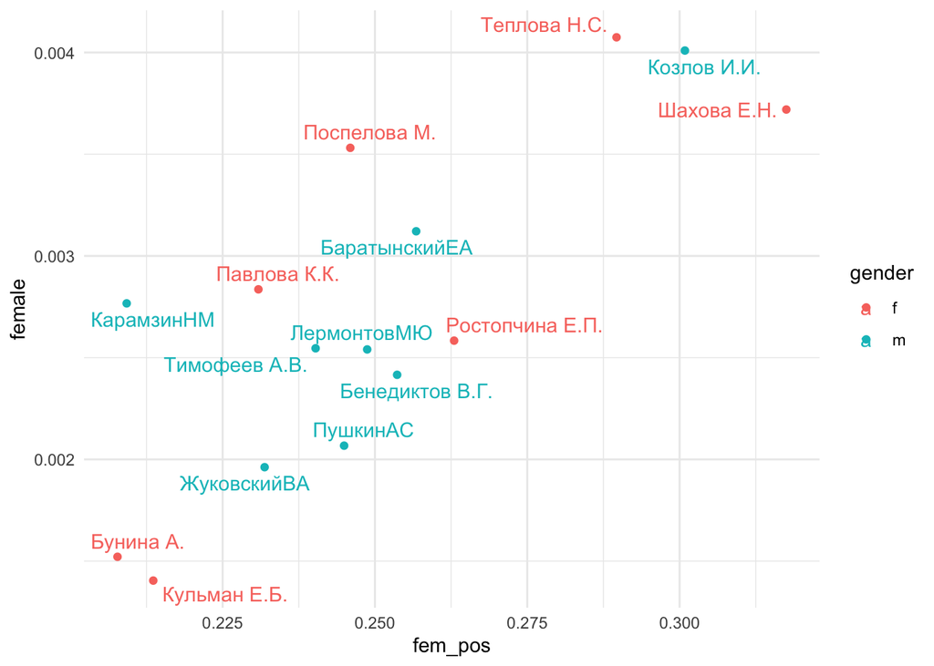

```r
fem_pos <- rowMeans(grouped_results[, c("prop_f_nouns", "prop_f_adj", "prop_f_verb", "prop_f_pron")])

grouped_results %>%
  select(author, gender, female) %>%
  cbind(fem_pos) %>%
  ggplot(aes(x = fem_pos, y = female, color = gender)) +
  geom_point() +
  geom_text_repel(aes(label = author))
```

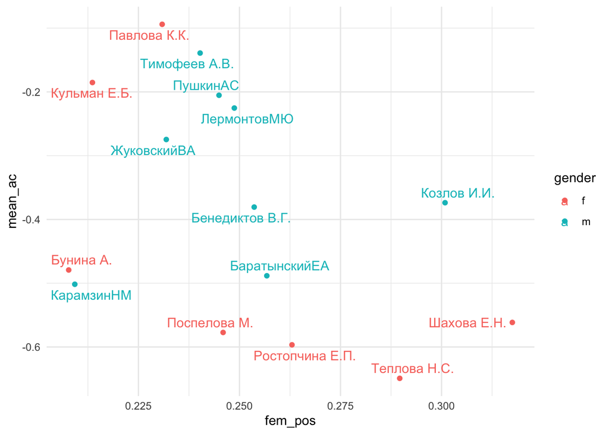

```r
grouped_results %>%
  select(author, gender, mean_ac) %>%
  cbind(fem_pos) %>%
  ggplot(aes(x = fem_pos, y = mean_ac, color = gender)) +
  geom_point() +
  geom_text_repel(aes(label = author))
```

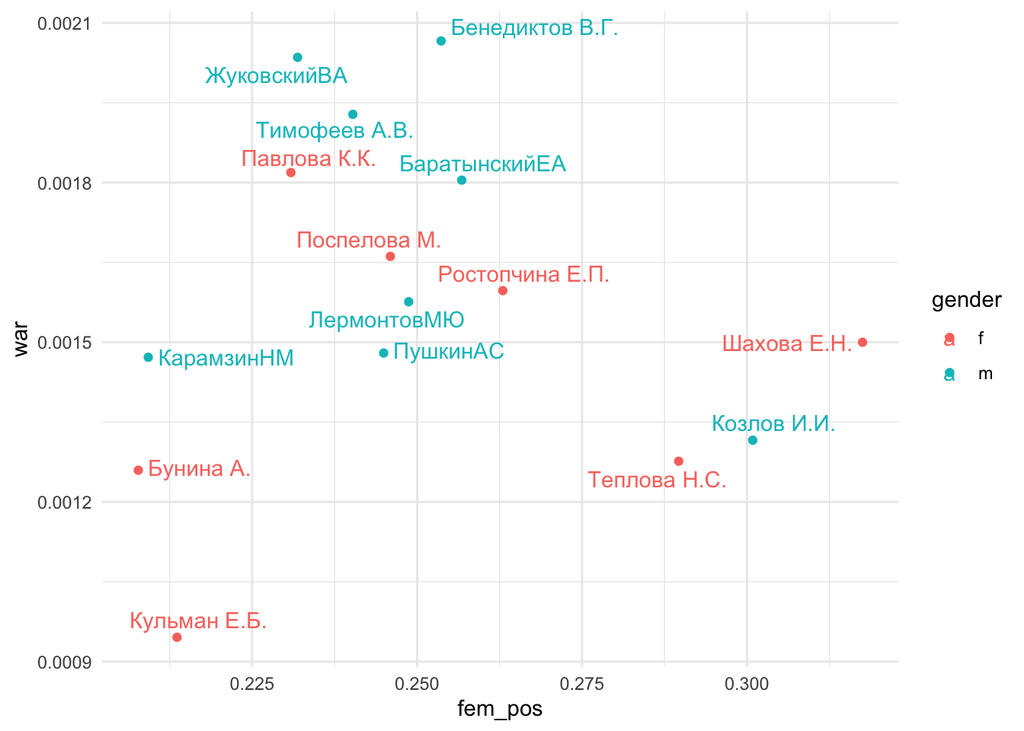

```r
grouped_results %>%
  select(author, gender, war) %>%
  cbind(fem_pos) %>%
  ggplot(aes(x = fem_pos, y = war, color = gender)) +
  geom_point() +
  geom_text_repel(aes(label = author))
```

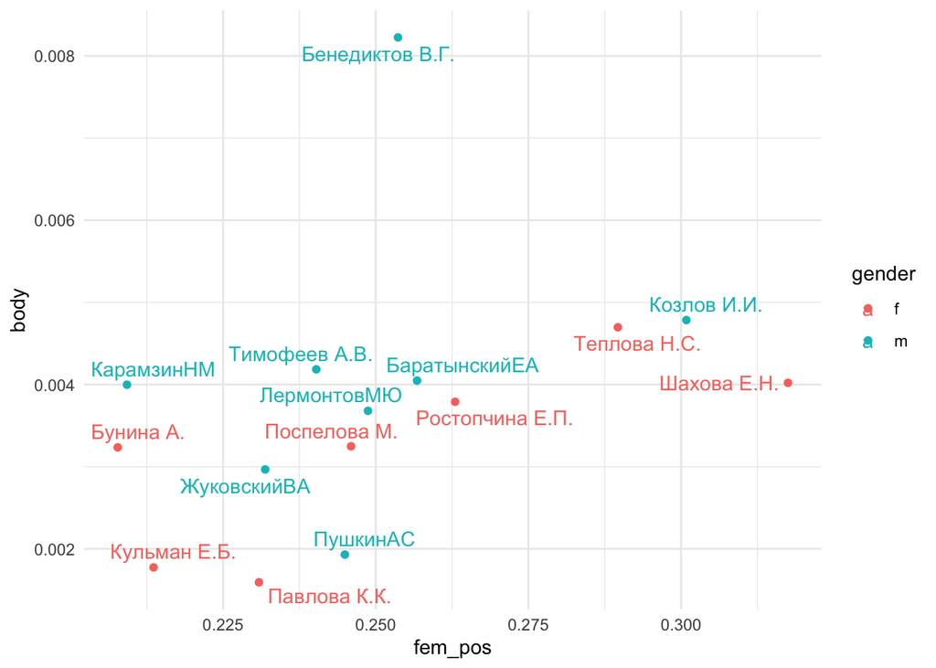

```r
grouped_results %>%
  select(author, gender, body) %>%
  cbind(fem_pos) %>%
  ggplot(aes(x = fem_pos, y = body, color = gender)) +
  geom_point() +
  geom_text_repel(aes(label = author))
```